# Shapiro_DATA607_Final_Project_Music_Streaming

Jacob Shapiro

2025-12-14

# Introduction

# Set up Spotify API & Import Data

I set up an app with my Spotify account through developer.spotify.com.

My Spotify ID & Secret - stored as environment variables in my Rstudio session

```r
spot_ID <- Sys.getenv("SPOTIFY_CLIENT_ID")
spot_secret <- Sys.getenv("SPOTIFY_CLIENT_SECRET")
```

## API Requests

### OAuth 2.0

Tried using RCurl package based on Spotify documentation using cURL. It wasn’t working so I tried using the ‘spotifyr’ package but due to recent changes to the API authorization, that package also wasn’t working. I ended up using the httr package and prompting Claude to produce a GET call similar to the example provided on the Spotify Web Developer page which was in javascript. To do OAuth 2.0 with current Spotify authorization you need to get permission by the user (me) and use a string from the resulting URL as the “authorization code”, which is used to generate an “access token” which works for 1 hour after the token generates.

Also was having issues with a proper redirect URI because Spotify won’t allow a ‘localhost’. Ended up being successful with http://127.0.0.1:8787 as a proxy for localhost because RStudio uses the 8787 port and 127.0.0.1 is a proxy for localhost.

### Request User Authorization

```r
# trying with Claude
# prompt: "write an r script that does a user authorization request to the spotify web api. build and send a GET request to the /authorize endpoint with the following parameters:Query ParameterRelevanceValueclient_idRequiredThe Client ID generated after registering your application.response_typeRequiredSet to code.redirect_uriRequiredThe URI to redirect to after the user grants or denies permission. This URI needs to have been entered in the Redirect URI allowlist that you specified when you registered your application (See the __app guide__). The value of redirect_uri here must exactly match one of the values you entered when you registered your application, including upper or lowercase, terminating slashes, and such."

# Your Spotify credentials
client_id <- spot_ID
client_secret <- spot_secret
redirect_uri <- "http://127.0.0.1:8787"
scopes <- "user-top-read user-read-recently-played user-library-read"
#these look to be the relevant scopes needed for data I want to pull - a forum post indicated that some scopes are problematic and I confirmed when trying to add them here

# Build the authorization URL
auth_url <- modify_url(
  "https://accounts.spotify.com/authorize",
  query = list(
    client_id = client_id,
    response_type = "code",
    redirect_uri = redirect_uri,
    scope = scopes
  )
)

# Print the authorization URL
cat("Please visit this URL to authorize the application:\n\n")
cat(auth_url, "\n\n")

# Automatically open in browser (optional)
browseURL(auth_url)

# Instructions for user
cat("After authorizing, you will be redirected to your redirect_uri.\n")
cat("Copy the 'code' parameter from the URL and use it to request an access token.\n")
cat("Example: http://localhost:8888/callback?code=AQBx7t...\n")
cat("The code is everything after '?code='\n")
```

### Request an access token

```r
# Claude prompt: "write an r script to request an access token from the spotify web api. The body of this POST request must contain the following parameters encoded in application/x-www-form-urlencoded: Body ParametersRelevanceValuegrant_typeRequiredThis field must contain the value "authorization_code".codeRequiredThe authorization code returned from the previous request.redirect_uriRequiredThis parameter is used for validation only (there is no actual redirection). The value of this parameter must exactly match the value of redirect_uri supplied when requesting the authorization code. The request must include the following HTTP headers: Header ParameterRelevanceValueAuthorizationRequiredBase 64 encoded string that contains the client ID and client secret key. The field must have the format: Authorization: Basic <base64 encoded client_id:client_secret>Content-TypeRequiredSet to application/x-www-form-urlencoded."

# Your Spotify credentials
client_id <- spot_ID
client_secret <- spot_secret
authorization_code <- "AQAk6f0_Ou06KA4NcugyXAccs2Z86Rf2DOYJ8pY1-AN3OCzW_tWWDscPJt5KJOxotB27CU5B_Z0O7KbNHpFMdV9qaskpChFn-1dZCXijzr4WIfgoBAL0XOB6OoYQzBpCBvW-i8dOkv2QjLnULVf38uvUlBLWMfXrMcebSZYgr_TfsXyGNOByt_93J1Vjn2Dq2NZz2KQ5coEuGCQVM6Ig5TiHTEn9GcM05ICz5tfQ8g_NiCe3NHk"
redirect_uri <- "http://127.0.0.1:8787"

# Create base64 encoded authorization header
auth_string <- paste0(client_id, ":", client_secret)
auth_encoded <- base64enc::base64encode(charToRaw(auth_string))

# Make POST request to get access token
response <- POST(
  url = "https://accounts.spotify.com/api/token",
  add_headers(
    Authorization = paste("Basic", auth_encoded),
    `Content-Type` = "application/x-www-form-urlencoded"
  ),
  body = list(
    grant_type = "authorization_code",
    code = authorization_code,
    redirect_uri = redirect_uri
  ),
  encode = "form"
)

# Parse the response
token_data <- content(response, "parsed")

# Extract access token
access_token <- token_data$access_token
refresh_token <- token_data$refresh_token

# Print results
print(paste("Access Token:", access_token))
```

```
## [1] "Access Token: BQARIprHwxZUTmVu1f99CHf0pYWN_P-L8fnusl03QysBbxbTXIvWYj4_8bW_cSRcsXSviSpd9m7E9W3JVvmKt9hCLDNwXL8iCLV69Kejnz4eZKly5MspkJ94B8STktekBIug5KGnf4K7kxF9qeqMBxe880N76fSt0Je1zymSpexQjLacPgKFxVerKNpMVYCrokel2m2RNdgpxHQmP-rcQomY7XBC7Cf6r4xx2F1l1zNKCr1QQegfYVLAABFKDg"
```

```r
print(paste("Refresh Token:", refresh_token))
```

```
## [1] "Refresh Token: AQDIFvieyFfUAYK8J0Hve7c5-g1Scq1befFfw00G6bttXmlm-HoidgUeFcMpo4Bcx3GimCdaHbHuWjFCJi656uL7E6yKln12jimfXuPHXJEFYiA-wq4NEpMsZupBeohnJbI"
```

```r
print(paste("Expires in:", token_data$expires_in, "seconds"))
```

```
## [1] "Expires in: 3600 seconds"
```

### Pull top artists

```r
# ChatGPT prompt: write an r script that mimics a javascript cURL request with the following parameters: curl --request GET \ --url https://api.spotify.com/v1/me/top/artists \ --header 'Authorization: Bearer 1POdFZRZbvb...qqillRxMr2z'
## based on Spotify Web API widget for javascript cURL code

# Spotify API endpoint
url <- "https://api.spotify.com/v1/me/top/artists?time_range=long_term&limit=50&offset=0" #using long_term for ~ a year

response <- GET(
  url,
  add_headers(Authorization = paste("Bearer", access_token))
)

# View status and content
print(status_code(response))
```

```
## [1] 200
```

```r
content <- content(response, as = "text", encoding = "UTF-8")

# Use jsonlite to put in readable format
data <- fromJSON(content, flatten = TRUE)

# Item "previous" is empty, taking it out
data2 <- data[-7]

# Make wide table
wide_artist_data <- data2 %>%
  as_tibble()
wide_artist_data <- wide_artist_data %>%
  unnest_wider(items, names_sep = "_")

# My top artists
my_top_artists <- wide_artist_data %>% select(items_name, items_popularity)
kable(head(my_top_artists))
```

| items_name | items_popularity |
| --- | --- |
| Valley | 56 |
| YUNGBLUD | 75 |
| Łaszewo | 65 |
| Kid Cudi | 81 |
| Jonas Brothers | 79 |
| Mac Miller | 84 |

### Pull top tracks

Important data for this is track, album, artist, and popularity

```r
# Same query just need to change URL

# Spotify API endpoint
url <- "https://api.spotify.com/v1/me/top/tracks?time_range=long_term&limit=50&offset=0" #using long_term for ~ a year

response <- GET(
  url,
  add_headers(Authorization = paste("Bearer", access_token))
)

# View status and content
print(status_code(response))
```

```
## [1] 200
```

```r
content <- content(response, as = "text", encoding = "UTF-8")

# Use jsonlite to put in readable format
data <- fromJSON(content, flatten = TRUE)

#Item "previous" is empty, taking it out
data2 <- data[-7]

# Want to get artists  and other data for each track - need to unnest.
wide_track_data <- data2 %>%
  as_tibble() %>%
  unnest_wider(items, names_sep = "_")

# Artists are in dataframe in list of lists. Tried multiple methods of unnesting, see commented at bottom of chunk for further details. Noted that data2[[1]][[1]][[i]][[3]] would return results I was interested in.
# Claude prompt: write a for loop in r to go 1-50 for i in data2[[1]][[1]][[i]][[3]] and store in dataframe
# Create empty dataframe to store results
artist_data <- list()

# Loop through 1 to 50
for (i in 1:50) {
  # Extract data from nested structure
  data_extract <- data2[[1]][[1]][[i]][[3]]

  # Convert to dataframe and add position
  df <- as.data.frame(data_extract)
  df$position <- i

  # Store in list
  artist_data[[i]] <- df
}

# Combine all dataframes
artist_data <- bind_rows(artist_data)

colnames(artist_data)[1] <- "artist"

# View result
kable(head(artist_data))
```

| artist | position |
| --- | --- |
| Rence | 1 |
| Dizzy | 2 |
| Stephen Sanchez | 3 |
| FIZZ | 4 |
| Pixey | 5 |
| Tayo Sound | 5 |

```r
#Successfully made dataframe of artists with position of track in data2

# #Unnest longer then making wide table might be easier?
# data3 <- data2 %>% as_tibble() %>% unnest_longer(items) %>% unnest_longer(items$artists)
# # head(data3)
# #This is providing a dataframe which contains lists of dataframes. Need to pull artist out of items$artists
#
# #Easier method - just make wider and extract "name" from dataframe from list in column items$artists (third item in the lists)
# wide_track_data <- data2 %>%
#   as_tibble() %>%
#   unnest_wider(items, names_sep = "_")
#
# colnames(data3)[1] <- "items_artists"
# artist_data <- sapply(data3$items_artists, function(x) {
#   sapply(x, function(df) df$name)
# })
#
# #data3 and down to here not working now. Trying new claude script
# library(purrr)
# # Method 1: Extract all artist names, keeping track structure
# artist_names <- data2$items %>%
#   map("artists") %>%  # Extract artists list from each item
#   map(~.x$name)       # Extract name column from each dataframe
# # Method 2: Create a dataframe with one row per artist
# artist_df <- tibble(
#   track_position = seq_along(data2$items),
#   artists = map(data2$items, "artists")
# ) %>%
#   unnest_longer(artists, indices_to = "artist_position") %>%
#   mutate(artist_name = artists$name) %>%
#   select(track_position, artist_position, artist_name)
#
# print(artist_df)
#
# #claude prompt: you have a dataframe "wide_track_data" which contains a column "items_artists" which is a list of lists with one dataframe per list. Write an r script to extract the value of the "name" object from each dataframe
# artist_data <- sapply(wide_track_data$items_artists, function(x) {
#   sapply(x, function(df) df$name)
# }) #successfully made list of artists
#
# #Make list of lists into a dataframe with artists and their respective element numbers
# #Claude prompt: you have a list "artist_data" of character lists. Write a simple r script with dplyr to make the values into a dataframe while keeping the position of "artist_data" for each artist
# track_artist_df <- tibble(artist_data = artist_data) %>%
#   mutate(row_id = row_number()) %>%
#   unnest_longer(artist_data, indices_to = "artist_position")
# head(track_artist_df)
```

Got artists. Now will make sub-table with track name, album, and popularity. Then will join with artist data.

```r
# My top track data
my_top_tracks <- wide_track_data %>% select(items_name, items_album.name, items_popularity)

# add position column to join with artist data
my_top_tracks <- my_top_tracks %>%
  mutate(position = row_number())
my_top_tracks_joined <- artist_data %>% left_join(my_top_tracks, by = c("position" = "position"))

kable(head(my_top_tracks_joined))
```

| artist | position | items_name | items_album.name | items_popularity |
| --- | --- | --- | --- | --- |
| Rence | 1 | TREBUCHET | TREBUCHET | 17 |
| Dizzy | 2 | Open Up Wide | Dizzy | 35 |
| Stephen Sanchez | 3 | See The Light | Easy On My Eyes | 61 |
| FIZZ | 4 | Rocket League | The Secret To Life | 23 |
| Pixey | 5 | Daisy Chain | Daisy Chain | 37 |
| Tayo Sound | 5 | Daisy Chain | Daisy Chain | 37 |

### Pull top genres

This goal cannot wholistically be achieved as Spotify does not have great data on genres and there is no specific genre endpoints. The only genre data available that I could find is those tagged to artists as seen below:

```r
# The empty rows are lists of character(0) which is giving trouble with filtering. Also hard to get rid of.
# Claude prompt: you have a column from a dataframe with each element being a list of a list. Extract the values in r. Some values are character(0)
genres <- map(wide_artist_data$items_genres, ~{
  unlisted <- unlist(.x)
  if(length(unlisted) == 0) NA else unlisted
})

genres_clean <- genres[!is.na(genres)]

# # Claude prompt: you have a list of lists "genres". Remove any nested lists with value of character(0) in r
# # Remove character(0) from nested lists
# genres_cleaned <- map(genres, ~.x[lengths(.x) > 0])
#
# # Then remove any top-level lists that became empty
# genres_cleaned <- genres_cleaned[lengths(genres_cleaned) > 0]
# head(genres_cleaned)

# Claude prompt: make those nested lists into a dataframe with each nested list as one row
# Convert nested lists to dataframe with one row per list
genres_df <- tibble(
  list_id = 1:length(genres_clean),
  genres = genres_clean
) %>%
  mutate(genres_string = map_chr(genres, ~paste(.x, collapse = ", ")))

kable(print(genres_df))
```

```
## # A tibble: 17 × 3
##    list_id genres    genres_string
##      <int> <list>    <chr>
##  1       1 <chr [1]> stutter house
##  2       2 <chr [2]> edm, electronic
##  3       3 <chr [6]> melodic bass, future bass, edm, chillstep, dubstep, progre…
##  4       4 <chr [2]> future bass, edm
##  5       5 <chr [1]> stutter house
##  6       6 <chr [1]> synthwave
##  7       7 <chr [1]> tropical house
##  8       8 <chr [3]> melodic bass, future bass, edm
##  9       9 <chr [2]> edm, progressive house
## 10      10 <chr [2]> rap, hip hop
## 11      11 <chr [1]> rap
## 12      12 <chr [1]> folk pop
## 13      13 <chr [1]> bedroom pop
## 14      14 <chr [3]> edm, melodic bass, future bass
## 15      15 <chr [2]> hyperpop, art pop
## 16      16 <chr [1]> tropical house
## 17      17 <chr [2]> future house, edm
```

| list_id | genres | genres_string |
| --- | --- | --- |
| 1 | stutter house | stutter house |
| 2 | edm , electronic | edm, electronic |
| 3 | melodic bass , future bass , edm , chillstep , dubstep , progressive trance | melodic bass, future bass, edm, chillstep, dubstep, progressive trance |
| 4 | future bass, edm | future bass, edm |
| 5 | stutter house | stutter house |
| 6 | synthwave | synthwave |
| 7 | tropical house | tropical house |
| 8 | melodic bass, future bass , edm | melodic bass, future bass, edm |
| 9 | edm , progressive house | edm, progressive house |
| 10 | rap , hip hop | rap, hip hop |
| 11 | rap | rap |
| 12 | folk pop | folk pop |
| 13 | bedroom pop | bedroom pop |
| 14 | edm , melodic bass, future bass | edm, melodic bass, future bass |
| 15 | hyperpop, art pop | hyperpop, art pop |
| 16 | tropical house | tropical house |
| 17 | future house, edm | future house, edm |

Only 17 of my top 50 artists had any genres tagged to them, most being electronic dance music artists. We’ll move forward with the project and do some analysis of popularity within the Spotify data itself to analyze mainstream-ness of my music taste.

# Import Billboard Data

Utilizing Billboard Year-End Hot 100 songs and artists lists.

Artists: https://www.billboard.com/charts/year-end/2025/top-artists/

```r
# Claude prompt: write an r script to scrape the top artist names from this billboard web page https://www.billboard.com/charts/year-end/2025/top-artists/

# URL to scrape
url <- "https://www.billboard.com/charts/year-end/2025/top-artists/"

# Read the webpage
page <- read_html(url)

# Extract artist names (adjust selector based on actual page structure)
artists <- page %>%
  html_nodes(".o-chart-results-list-row h3") %>%
  html_text() %>%
  trimws()

# Create dataframe
bb_artists <- tibble(
  rank = 1:length(artists),
  artist_name = artists
)

kable(head(bb_artists, 10))
```

| rank | artist_name |
| --- | --- |
| 1 | Morgan Wallen |
| 2 | Kendrick Lamar |
| 3 | Taylor Swift |
| 4 | Sabrina Carpenter |
| 5 | SZA |
| 6 | Drake |
| 7 | Bad Bunny |
| 8 | Billie Eilish |
| 9 | Tyler, The Creator |
| 10 | The Weeknd |

Songs: https://www.billboard.com/charts/year-end/2025/hot-100-songs/

```r
# URL to scrape
url <- "https://www.billboard.com/charts/year-end/2025/hot-100-songs/"

# Read the webpage
page <- read_html(url)

# Extract artist names (adjust selector based on actual page structure)
songs <- page %>%
  html_nodes(".o-chart-results-list-row h3") %>%
  html_text() %>%
  trimws()

# Create dataframe
bb_songs <- tibble(
  rank = 1:length(songs),
  song_name = songs
)

kable(head(bb_songs, 10))
```

| rank | song_name |
| --- | --- |
| 1 | Die With A Smile |
| 2 | Luther |
| 3 | A Bar Song (Tipsy) |
| 4 | Lose Control |
| 5 | Birds Of A Feather |
| 6 | Beautiful Things |
| 7 | Ordinary |
| 8 | I Had Some Help |
| 9 | APT. |
| 10 | Pink Pony Club |

# Analysis

We’ll be investigating overlaps of songs and artists with Billboards 2025 year-end lists from above with my Spotify top 50 songs and artists. Then we’ll dig a little deeper into the Spotify data obtained.

## Song Overlap

```r
matched_songs <- my_top_tracks %>%
  inner_join(bb_songs, by = c("items_name" = "song_name"))

kable(head(matched_songs))
```

| items_name | items_album.name | items_popularity | position | rank |
| --- | --- | --- | --- | --- |

We find that there’s no overlapping songs.

## Artist Overlap

```r
matched_artists <- my_top_artists %>%
  inner_join(bb_artists, by = c("items_name" = "artist_name"))

kable(head(matched_artists))
```

| items_name | items_popularity | rank |
| --- | --- | --- |
| Post Malone | 88 | 15 |
| Lil Wayne | 88 | 71 |
| Taylor Swift | 100 | 3 |
| Charli xcx | 84 | 42 |

There are 4 overlapping artists between Billboard Top 100 and my top Spotify artists for 2025. All artists have relative popularity scores of at least 84 on Spotify.

## Spotify Popularity

### Popularity Graph

Spotify provides popularity scores for both songs and artists so let’s graph my popularity map for both.

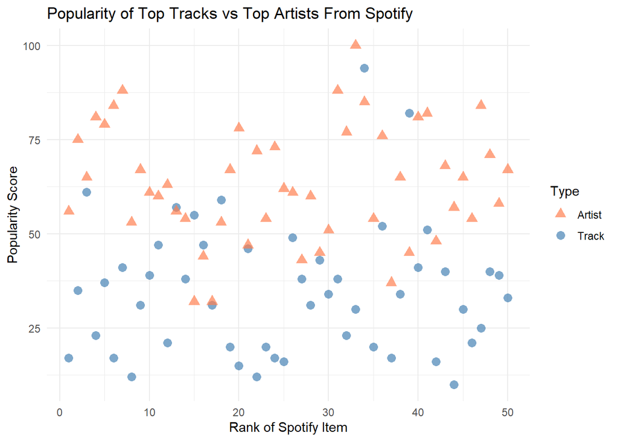

```r
# Claude prompt: write a simple r script with ggplot2 to graph a scatterplot of "items_popularity" for two sets of data "my_top_tracks" and "my_top_artists", each set should have its own symbol

# Add a type column to each dataset
my_top_tracks <- my_top_tracks %>%
  mutate(type = "Track",
         index = row_number())

my_top_artists <- my_top_artists %>%
  mutate(type = "Artist",
         index = row_number())

# Combine datasets
combined_data <- bind_rows(my_top_tracks, my_top_artists)

# Create scatterplot
ggplot(combined_data, aes(x = index, y = items_popularity, color = type, shape = type)) +
  geom_point(size = 3, alpha = 0.7) +
  labs(title = "Popularity of Top Tracks vs Top Artists From Spotify",
       x = "Rank of Spotify Item",
       y = "Popularity Score",
       color = "Type",
       shape = "Type") +
  theme_minimal() +
  scale_color_manual(values = c("Track" = "steelblue", "Artist" = "coral")) +
  scale_shape_manual(values = c("Track" = 16, "Artist" = 17))  # 16=circle, 17=triangle
```

From the graph I’m seeing the minority of tracks above the popularity score of 50, but seeing the inverse for artists. The popularity of a track is a value between 0 and 100, with 100 being the most popular. The popularity is calculated by algorithm and is based, in the most part, on the total number of plays the track has had and how recent those plays are. Based on this, we can assume 50 is the average popularity of the songs and artists at the time of pulling data from the API. Let’s pull these respective lists above and below 50.

```r
# Above 50 popularity songs

table <- my_top_tracks_joined %>% filter(items_popularity > 50) %>% select(artist, items_name, items_popularity, position) %>% arrange(desc(items_popularity))
kable(table)
```

| artist | items_name | items_popularity | position |
| --- | --- | --- | --- |
| Djo | End of Beginning | 94 | 34 |
| Dasha | Austin (Boots Stop Workin’) | 82 | 39 |
| Stephen Sanchez | See The Light | 61 | 3 |
| One Direction | Act My Age | 59 | 18 |
| YUNGBLUD | god save me, but don’t drown me out | 57 | 13 |
| Novo Amor | Halloween | 55 | 15 |
| YUNGBLUD | When We Die (Can We Still Get High?) (feat. Lil Yachty) | 52 | 36 |
| Lil Yachty | When We Die (Can We Still Get High?) (feat. Lil Yachty) | 52 | 36 |
| Kygo | Never Really Loved Me (with Dean Lewis) | 51 | 41 |
| Dean Lewis | Never Really Loved Me (with Dean Lewis) | 51 | 41 |

```r
# Below 50 popularity artists

table <- my_top_artists %>% filter(items_popularity < 50) %>% select(items_name, items_popularity, index) %>% arrange(desc(items_popularity))
kable(table)
```

| items_name | items_popularity | index |
| --- | --- | --- |
| MICHELLE | 48 | 42 |
| ayokay | 47 | 21 |
| Lauren Sanderson | 45 | 29 |
| Landon Conrath | 45 | 39 |
| demotapes | 44 | 16 |
| The Wldlfe | 43 | 27 |
| modernlove. | 37 | 37 |
| Miki Fiki | 32 | 15 |
| GUS | 32 | 17 |

Most of the songs make sense for being over a score of 50 - End of Beginning and Austin (Boots Stop Workin’) were songs that got popular through social media and stayed on playlists, One Direction is always popular, and YUNGBLUD and Kygo are relatively popular so even older music makes sense to still be popular. I was surprised by See The Light by Stephen Sanchez and Halloween by Novo Amor being so popular. Upon further inspection, Stephen Sanchez has almost 20 million monthly listeners and See The Light has around 50 million plays, and Novo Amor has 10 million monthly listeners.

The artists below popularity score of 50 all have less than a million monthly listeners, most less than 500k monthly, so that makes sense.

### T Tests

Assuming an average popularity score of 50, we can use a t test to statistically test how mainstream my music taste is.

#### Songs

```r
tracks_ttest <- t.test(my_top_tracks$items_popularity, mu = 50)
print(tracks_ttest)
```

```
##
##  One Sample t-test
##
## data:  my_top_tracks$items_popularity
## t = -6.1262, df = 49, p-value = 1.495e-07
## alternative hypothesis: true mean is not equal to 50
## 95 percent confidence interval:
##  29.94677 39.85323
## sample estimates:
## mean of x
##      34.9
```

```r
# Key values
cat("\n--- Summary ---\n")
```

```
##
## --- Summary ---
```

```r
cat("Sample Mean:", mean(my_top_tracks$items_popularity), "\n")
```

```
## Sample Mean: 34.9
```

```r
cat("t-statistic:", tracks_ttest$statistic, "\n")
```

```
## t-statistic: -6.126224
```

```r
cat("p-value:", tracks_ttest$p.value, "\n")
```

```
## p-value: 1.495048e-07
```

```r
cat("95% Confidence Interval:", tracks_ttest$conf.int[1], "to", tracks_ttest$conf.int[2], "\n")
```

```
## 95% Confidence Interval: 29.94677 to 39.85323
```

#### Artists

```r
artist_ttest <- t.test(my_top_artists$items_popularity, mu = 50)
print(artist_ttest)
```

```
##
##  One Sample t-test
##
## data:  my_top_artists$items_popularity
## t = 6.221, df = 49, p-value = 1.067e-07
## alternative hypothesis: true mean is not equal to 50
## 95 percent confidence interval:
##  59.1797 67.9403
## sample estimates:
## mean of x
##     63.56
```

```r
# Key values
cat("\n--- Summary ---\n")
```

```
##
## --- Summary ---
```

```r
cat("Sample Mean:", mean(my_top_artists$items_popularity), "\n")
```

```
## Sample Mean: 63.56
```

```r
cat("t-statistic:", artist_ttest$statistic, "\n")
```

```
## t-statistic: 6.221001
```

```r
cat("p-value:", artist_ttest$p.value, "\n")
```

```
## p-value: 1.067267e-07
```

```r
cat("95% Confidence Interval:", artist_ttest$conf.int[1], "to", artist_ttest$conf.int[2], "\n")
```

```
## 95% Confidence Interval: 59.1797 to 67.9403
```

# Conclusions

Overall, we saw that none of of my 50 top songs were in Billboard’s Hot 100, and only 4 artists were in Billboard’s Top 100 Artists for 2025. When it comes to Spotify-specific data, I am statistically more likely to listen to artists that have a popularity score of over 50, but when it comes to songs I’m likely to listen to songs with a popularity score of less than 50. Keeping in mind this data set was only my top 50 songs and artists, it’s possible the majority of artists I listen to have less than a popularity score of 50 but we’d need to pull in more data to come to a conclusion on that. However, based on the data I think it’s safe to infer the majority of songs I listen to have a popularity score less than 50 because the songs most popular for me would also be popular for everyone else if I had mainstream music taste.

It is pertinent to think of confounding factors and the nature of the music industry and how that can impact our inferences. Spotify has over 11 million artists and creators worldwide, but over 100 million tracks available with ~60,000 new tracks uploaded daily. There’s only so much time in the day for people to listen to all these tracks - my Spotify wrapped said I only listened to songs and podcasts (mainly songs) for 55,000 minutes. Spotify also heavily utilizes algorithms for recommendations on new tracks for users. Their recommendations can come after you’ve finished a playlist, if you select one of the several personally targeted daily-generated playlists, or even via their Spotify DJ feature. I can conclude that my music taste isn’t mainstream based on a p-value and assumptions, but I am still heavily influenced by the music that Spotify feeds me. I tend to listen to the Daily Mixes, daylist, Discover Weekly, and sometimes don’t notice when a playlist ends. With this in mind, I have my artists I follow and decide to listen to their music here and there, but how mainstream my music taste is is mostly determined by Spotify’s algorithm.